# Risk Factor Analysis

## Outcome Variable

**Outcome Variable:** wast_rec90d

## Predictor Variables

**Intervention Variable:** exclfeed36

**Adjustment Set:**

- arm
- sex
- W_mage
- meducyrs
- feducyrs
- hhwealth_quart
- hfoodsec
- W_mhtcm
- vagbrth
- W_gagebrth
- W_birthwt
- W_birthlen
- W_nrooms
- W_nchldlt5
- month
- brthmon
- W_parity
- impfloor
- impsan
- safeh20
- delta_W_mage
- delta_meducyrs
- delta_feducyrs
- delta_hhwealth_quart
- delta_hfoodsec
- delta_W_mhtcm
- delta_vagbrth
- delta_W_gagebrth
- delta_W_birthwt
- delta_W_birthlen
- delta_W_nrooms
- delta_W_nchldlt5
- delta_month
- delta_brthmon
- delta_W_parity
- delta_impfloor
- delta_impsan
- delta_safeh20

## Stratifying Variables

The analysis was stratified on these variable(s):

- agecat
- studyid
- country

## Data Summary

| agecat | studyid | country | exclfeed36 | wast_rec90d | n_cell | n |
| --- | --- | --- | --- | --- | --- | --- |
| 0-24 months | ki0047075b-MAL-ED | BANGLADESH | 0 | 0 | 29 | 122 |
| 0-24 months | ki0047075b-MAL-ED | BANGLADESH | 0 | 1 | 55 | 122 |
| 0-24 months | ki0047075b-MAL-ED | BANGLADESH | 1 | 0 | 15 | 122 |
| 0-24 months | ki0047075b-MAL-ED | BANGLADESH | 1 | 1 | 23 | 122 |
| 0-24 months | ki0047075b-MAL-ED | BRAZIL | 0 | 0 | 6 | 23 |
| 0-24 months | ki0047075b-MAL-ED | BRAZIL | 0 | 1 | 17 | 23 |
| 0-24 months | ki0047075b-MAL-ED | BRAZIL | 1 | 0 | 0 | 23 |
| 0-24 months | ki0047075b-MAL-ED | BRAZIL | 1 | 1 | 0 | 23 |
| 0-24 months | ki0047075b-MAL-ED | INDIA | 0 | 0 | 70 | 177 |
| 0-24 months | ki0047075b-MAL-ED | INDIA | 0 | 1 | 104 | 177 |
| 0-24 months | ki0047075b-MAL-ED | INDIA | 1 | 0 | 0 | 177 |
| 0-24 months | ki0047075b-MAL-ED | INDIA | 1 | 1 | 3 | 177 |
| 0-24 months | ki0047075b-MAL-ED | NEPAL | 0 | 0 | 20 | 93 |
| 0-24 months | ki0047075b-MAL-ED | NEPAL | 0 | 1 | 72 | 93 |
| 0-24 months | ki0047075b-MAL-ED | NEPAL | 1 | 0 | 0 | 93 |
| 0-24 months | ki0047075b-MAL-ED | NEPAL | 1 | 1 | 1 | 93 |
| 0-24 months | ki0047075b-MAL-ED | PERU | 0 | 0 | 6 | 32 |
| 0-24 months | ki0047075b-MAL-ED | PERU | 0 | 1 | 26 | 32 |
| 0-24 months | ki0047075b-MAL-ED | PERU | 1 | 0 | 0 | 32 |
| 0-24 months | ki0047075b-MAL-ED | PERU | 1 | 1 | 0 | 32 |
| 0-24 months | ki0047075b-MAL-ED | SOUTH AFRICA | 0 | 0 | 13 | 78 |
| 0-24 months | ki0047075b-MAL-ED | SOUTH AFRICA | 0 | 1 | 65 | 78 |
| 0-24 months | ki0047075b-MAL-ED | SOUTH AFRICA | 1 | 0 | 0 | 78 |
| 0-24 months | ki0047075b-MAL-ED | SOUTH AFRICA | 1 | 1 | 0 | 78 |
| 0-24 months | ki0047075b-MAL-ED | TANZANIA, UNITED REPUBLIC OF | 0 | 0 | 8 | 45 |
| 0-24 months | ki0047075b-MAL-ED | TANZANIA, UNITED REPUBLIC OF | 0 | 1 | 37 | 45 |
| 0-24 months | ki0047075b-MAL-ED | TANZANIA, UNITED REPUBLIC OF | 1 | 0 | 0 | 45 |
| 0-24 months | ki0047075b-MAL-ED | TANZANIA, UNITED REPUBLIC OF | 1 | 1 | 0 | 45 |
| 0-24 months | ki1000108-CMC-V-BCS-2002 | INDIA | 0 | 0 | 0 | 5 |
| 0-24 months | ki1000108-CMC-V-BCS-2002 | INDIA | 0 | 1 | 0 | 5 |

[output cut: 174 more lines]

The following strata were considered:

- agecat: 0-24 months, studyid: ki0047075b-MAL-ED, country: BANGLADESH
- agecat: 0-24 months, studyid: ki0047075b-MAL-ED, country: BRAZIL
- agecat: 0-24 months, studyid: ki0047075b-MAL-ED, country: INDIA
- agecat: 0-24 months, studyid: ki0047075b-MAL-ED, country: NEPAL
- agecat: 0-24 months, studyid: ki0047075b-MAL-ED, country: PERU
- agecat: 0-24 months, studyid: ki0047075b-MAL-ED, country: SOUTH AFRICA
- agecat: 0-24 months, studyid: ki0047075b-MAL-ED, country: TANZANIA, UNITED REPUBLIC OF
- agecat: 0-24 months, studyid: ki1000108-CMC-V-BCS-2002, country: INDIA
- agecat: 0-24 months, studyid: ki1000108-IRC, country: INDIA
- agecat: 0-24 months, studyid: ki1000109-EE, country: PAKISTAN
- agecat: 0-24 months, studyid: ki1000304b-SAS-FoodSuppl, country: INDIA
- agecat: 0-24 months, studyid: ki1017093b-PROVIDE, country: BANGLADESH
- agecat: 0-24 months, studyid: ki1101329-Keneba, country: GAMBIA
- agecat: 0-24 months, studyid: ki1113344-GMS-Nepal, country: NEPAL
- agecat: 0-24 months, studyid: ki1148112-LCNI-5, country: MALAWI
- agecat: 0-24 months, studyid: kiGH5241-JiVitA-3, country: BANGLADESH
- agecat: 0-24 months, studyid: kiGH5241-JiVitA-4, country: BANGLADESH
- agecat: 0-6 months, studyid: ki0047075b-MAL-ED, country: BANGLADESH
- agecat: 0-6 months, studyid: ki0047075b-MAL-ED, country: BRAZIL
- agecat: 0-6 months, studyid: ki0047075b-MAL-ED, country: INDIA
- agecat: 0-6 months, studyid: ki0047075b-MAL-ED, country: NEPAL
- agecat: 0-6 months, studyid: ki0047075b-MAL-ED, country: PERU
- agecat: 0-6 months, studyid: ki0047075b-MAL-ED, country: SOUTH AFRICA
- agecat: 0-6 months, studyid: ki0047075b-MAL-ED, country: TANZANIA, UNITED REPUBLIC OF
- agecat: 0-6 months, studyid: ki1000108-CMC-V-BCS-2002, country: INDIA
- agecat: 0-6 months, studyid: ki1000108-IRC, country: INDIA
- agecat: 0-6 months, studyid: ki1000109-EE, country: PAKISTAN
- agecat: 0-6 months, studyid: ki1000304b-SAS-FoodSuppl, country: INDIA
- agecat: 0-6 months, studyid: ki1017093b-PROVIDE, country: BANGLADESH
- agecat: 0-6 months, studyid: ki1101329-Keneba, country: GAMBIA
- agecat: 0-6 months, studyid: ki1113344-GMS-Nepal, country: NEPAL
- agecat: 0-6 months, studyid: ki1148112-LCNI-5, country: MALAWI
- agecat: 0-6 months, studyid: kiGH5241-JiVitA-3, country: BANGLADESH
- agecat: 0-6 months, studyid: kiGH5241-JiVitA-4, country: BANGLADESH
- agecat: 6-24 months, studyid: ki0047075b-MAL-ED, country: BANGLADESH
- agecat: 6-24 months, studyid: ki0047075b-MAL-ED, country: BRAZIL
- agecat: 6-24 months, studyid: ki0047075b-MAL-ED, country: INDIA
- agecat: 6-24 months, studyid: ki0047075b-MAL-ED, country: NEPAL
- agecat: 6-24 months, studyid: ki0047075b-MAL-ED, country: PERU
- agecat: 6-24 months, studyid: ki0047075b-MAL-ED, country: SOUTH AFRICA
- agecat: 6-24 months, studyid: ki0047075b-MAL-ED, country: TANZANIA, UNITED REPUBLIC OF
- agecat: 6-24 months, studyid: ki1000108-CMC-V-BCS-2002, country: INDIA
- agecat: 6-24 months, studyid: ki1000108-IRC, country: INDIA
- agecat: 6-24 months, studyid: ki1000109-EE, country: PAKISTAN
- agecat: 6-24 months, studyid: ki1000304b-SAS-FoodSuppl, country: INDIA
- agecat: 6-24 months, studyid: ki1017093b-PROVIDE, country: BANGLADESH
- agecat: 6-24 months, studyid: ki1101329-Keneba, country: GAMBIA
- agecat: 6-24 months, studyid: ki1113344-GMS-Nepal, country: NEPAL
- agecat: 6-24 months, studyid: ki1148112-LCNI-5, country: MALAWI
- agecat: 6-24 months, studyid: kiGH5241-JiVitA-3, country: BANGLADESH
- agecat: 6-24 months, studyid: kiGH5241-JiVitA-4, country: BANGLADESH

### Dropped Strata

Some strata were dropped due to rare outcomes:

- agecat: 0-24 months, studyid: ki0047075b-MAL-ED, country: BRAZIL
- agecat: 0-24 months, studyid: ki0047075b-MAL-ED, country: INDIA
- agecat: 0-24 months, studyid: ki0047075b-MAL-ED, country: NEPAL
- agecat: 0-24 months, studyid: ki0047075b-MAL-ED, country: PERU
- agecat: 0-24 months, studyid: ki0047075b-MAL-ED, country: SOUTH AFRICA
- agecat: 0-24 months, studyid: ki0047075b-MAL-ED, country: TANZANIA, UNITED REPUBLIC OF
- agecat: 0-24 months, studyid: ki1000108-CMC-V-BCS-2002, country: INDIA
- agecat: 0-24 months, studyid: ki1000108-IRC, country: INDIA
- agecat: 0-24 months, studyid: ki1000304b-SAS-FoodSuppl, country: INDIA
- agecat: 0-24 months, studyid: ki1148112-LCNI-5, country: MALAWI
- agecat: 0-6 months, studyid: ki0047075b-MAL-ED, country: BANGLADESH
- agecat: 0-6 months, studyid: ki0047075b-MAL-ED, country: BRAZIL
- agecat: 0-6 months, studyid: ki0047075b-MAL-ED, country: INDIA
- agecat: 0-6 months, studyid: ki0047075b-MAL-ED, country: NEPAL
- agecat: 0-6 months, studyid: ki0047075b-MAL-ED, country: PERU
- agecat: 0-6 months, studyid: ki0047075b-MAL-ED, country: SOUTH AFRICA
- agecat: 0-6 months, studyid: ki0047075b-MAL-ED, country: TANZANIA, UNITED REPUBLIC OF
- agecat: 0-6 months, studyid: ki1000108-CMC-V-BCS-2002, country: INDIA
- agecat: 0-6 months, studyid: ki1000108-IRC, country: INDIA
- agecat: 0-6 months, studyid: ki1000304b-SAS-FoodSuppl, country: INDIA
- agecat: 0-6 months, studyid: ki1017093b-PROVIDE, country: BANGLADESH
- agecat: 0-6 months, studyid: ki1148112-LCNI-5, country: MALAWI
- agecat: 6-24 months, studyid: ki0047075b-MAL-ED, country: BRAZIL
- agecat: 6-24 months, studyid: ki0047075b-MAL-ED, country: INDIA
- agecat: 6-24 months, studyid: ki0047075b-MAL-ED, country: NEPAL
- agecat: 6-24 months, studyid: ki0047075b-MAL-ED, country: PERU
- agecat: 6-24 months, studyid: ki0047075b-MAL-ED, country: SOUTH AFRICA
- agecat: 6-24 months, studyid: ki0047075b-MAL-ED, country: TANZANIA, UNITED REPUBLIC OF
- agecat: 6-24 months, studyid: ki1000108-CMC-V-BCS-2002, country: INDIA
- agecat: 6-24 months, studyid: ki1000108-IRC, country: INDIA
- agecat: 6-24 months, studyid: ki1000304b-SAS-FoodSuppl, country: INDIA
- agecat: 6-24 months, studyid: ki1148112-LCNI-5, country: MALAWI
- agecat: 6-24 months, studyid: kiGH5241-JiVitA-3, country: BANGLADESH

## Methods Detail

We’re interested in the causal parameters $E[Y_a]$ for all values of $a \in \mathcal{A}$. These parameters represent the mean outcome if, possibly contrary to fact, we intervened to set all units to have $A=a$. Under the randomization and positivity assumptions, these are identified by the statistical parameters $\psi_a=E_W[E_{Y|A,W}(Y|A=a,W)]$. In addition, we’re interested in the mean of $Y$, $E[Y]$ under no intervention (the observed mean). We will estimate these parameters by using SuperLearner to fit the relevant likelihood factors – $E_{Y|A,W}(Y|A=a,W)$ and $p(A=a|W)$, and then updating our likelihood fit using a joint TMLE.

For unadjusted analyses ($W=\{\}$), initial likelihoods were estimated using Lrnr_glm to estimate the simple $E(Y|A)$ and Lrnr_mean to estimate $p(A)$. For adjusted analyses, a small library containing Lrnr_glmnet, Lrnr_xgboost, and Lrnr_mean was used.

Having estimated these parameters, we will then use the delta method to estimate relative risks and attributable risks relative to a prespecified baseline level of $A$.

# Results Detail

## Results Plots

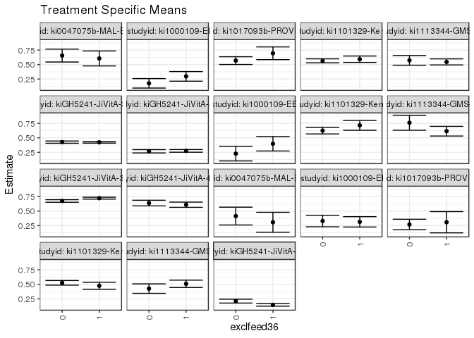

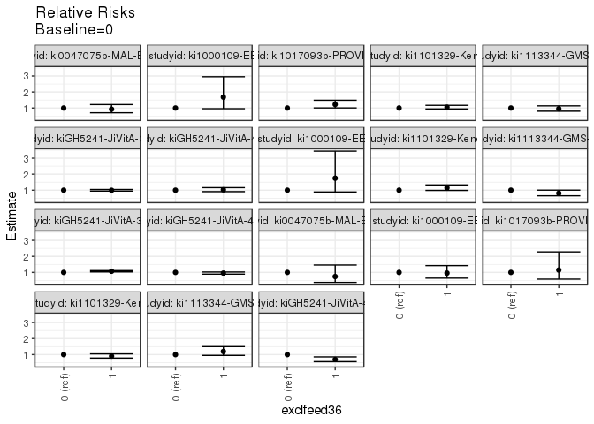

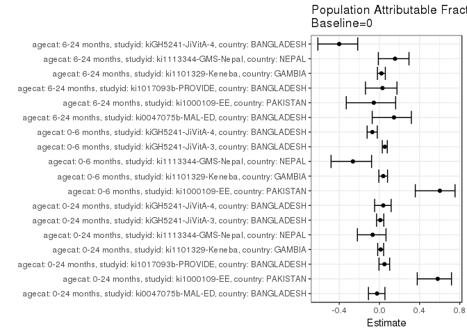

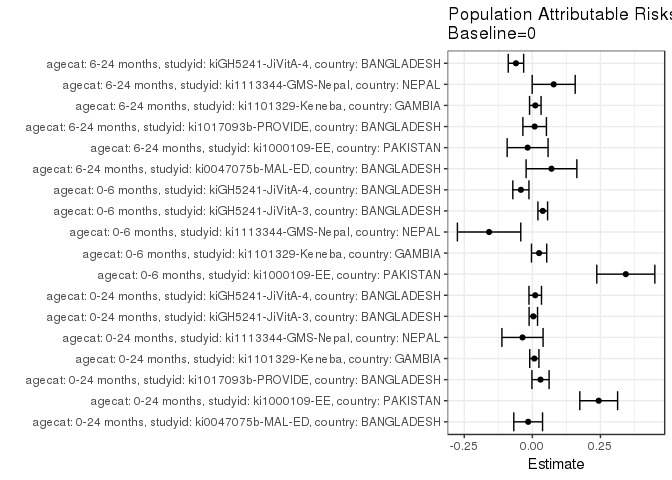

## Results Table

### Parameter: TSM

| agecat | studyid | country | intervention_level | baseline_level | estimate | ci_lower | ci_upper |
| --- | --- | --- | --- | --- | --- | --- | --- |
| 0-24 months | ki0047075b-MAL-ED | BANGLADESH | 0 | NA | 0.6547619 | 0.5435887 | 0.7659351 |
| 0-24 months | ki0047075b-MAL-ED | BANGLADESH | 1 | NA | 0.6052632 | 0.4761138 | 0.7344125 |
| 0-24 months | ki1000109-EE | PAKISTAN | 0 | NA | 0.1760068 | 0.0942436 | 0.2577700 |
| 0-24 months | ki1000109-EE | PAKISTAN | 1 | NA | 0.2960634 | 0.2127635 | 0.3793633 |
| 0-24 months | ki1017093b-PROVIDE | BANGLADESH | 0 | NA | 0.5680253 | 0.5011915 | 0.6348591 |
| 0-24 months | ki1017093b-PROVIDE | BANGLADESH | 1 | NA | 0.6942724 | 0.5847070 | 0.8038378 |
| 0-24 months | ki1101329-Keneba | GAMBIA | 0 | NA | 0.5642164 | 0.5299398 | 0.5984929 |
| 0-24 months | ki1101329-Keneba | GAMBIA | 1 | NA | 0.5920094 | 0.5367565 | 0.6472624 |
| 0-24 months | ki1113344-GMS-Nepal | NEPAL | 0 | NA | 0.5718014 | 0.4880388 | 0.6555641 |
| 0-24 months | ki1113344-GMS-Nepal | NEPAL | 1 | NA | 0.5450953 | 0.4929086 | 0.5972820 |
| 0-24 months | kiGH5241-JiVitA-3 | BANGLADESH | 0 | NA | 0.4257133 | 0.4063441 | 0.4450825 |
| 0-24 months | kiGH5241-JiVitA-3 | BANGLADESH | 1 | NA | 0.4228370 | 0.4088281 | 0.4368459 |
| 0-24 months | kiGH5241-JiVitA-4 | BANGLADESH | 0 | NA | 0.2676497 | 0.2388933 | 0.2964061 |
| 0-24 months | kiGH5241-JiVitA-4 | BANGLADESH | 1 | NA | 0.2745939 | 0.2514446 | 0.2977431 |
| 0-6 months | ki1000109-EE | PAKISTAN | 0 | NA | 0.2270045 | 0.1013598 | 0.3526492 |
| 0-6 months | ki1000109-EE | PAKISTAN | 1 | NA | 0.3970595 | 0.2723954 | 0.5217237 |
| 0-6 months | ki1101329-Keneba | GAMBIA | 0 | NA | 0.6240834 | 0.5664336 | 0.6817332 |
| 0-6 months | ki1101329-Keneba | GAMBIA | 1 | NA | 0.7148110 | 0.6299451 | 0.7996770 |
| 0-6 months | ki1113344-GMS-Nepal | NEPAL | 0 | NA | 0.7601171 | 0.6305567 | 0.8896775 |
| 0-6 months | ki1113344-GMS-Nepal | NEPAL | 1 | NA | 0.6141902 | 0.5308761 | 0.6975042 |
| 0-6 months | kiGH5241-JiVitA-3 | BANGLADESH | 0 | NA | 0.6741128 | 0.6518026 | 0.6964229 |
| 0-6 months | kiGH5241-JiVitA-3 | BANGLADESH | 1 | NA | 0.7229651 | 0.7065672 | 0.7393630 |
| 0-6 months | kiGH5241-JiVitA-4 | BANGLADESH | 0 | NA | 0.6378798 | 0.5895427 | 0.6862169 |
| 0-6 months | kiGH5241-JiVitA-4 | BANGLADESH | 1 | NA | 0.6092069 | 0.5642595 | 0.6541543 |
| 6-24 months | ki0047075b-MAL-ED | BANGLADESH | 0 | NA | 0.4136842 | 0.2601563 | 0.5672120 |
| 6-24 months | ki0047075b-MAL-ED | BANGLADESH | 1 | NA | 0.3067089 | 0.1346010 | 0.4788169 |
| 6-24 months | ki1000109-EE | PAKISTAN | 0 | NA | 0.3282596 | 0.2287448 | 0.4277743 |
| 6-24 months | ki1000109-EE | PAKISTAN | 1 | NA | 0.3142744 | 0.2248069 | 0.4037418 |
| 6-24 months | ki1017093b-PROVIDE | BANGLADESH | 0 | NA | 0.2680412 | 0.1773699 | 0.3587126 |
| 6-24 months | ki1017093b-PROVIDE | BANGLADESH | 1 | NA | 0.3076923 | 0.1243207 | 0.4910639 |
| 6-24 months | ki1101329-Keneba | GAMBIA | 0 | NA | 0.5261840 | 0.4862426 | 0.5661254 |
| 6-24 months | ki1101329-Keneba | GAMBIA | 1 | NA | 0.4753332 | 0.4148075 | 0.5358588 |
| 6-24 months | ki1113344-GMS-Nepal | NEPAL | 0 | NA | 0.4260531 | 0.3443138 | 0.5077924 |
| 6-24 months | ki1113344-GMS-Nepal | NEPAL | 1 | NA | 0.5089390 | 0.4457398 | 0.5721382 |
| 6-24 months | kiGH5241-JiVitA-4 | BANGLADESH | 0 | NA | 0.2105352 | 0.1771927 | 0.2438777 |
| 6-24 months | kiGH5241-JiVitA-4 | BANGLADESH | 1 | NA | 0.1454760 | 0.1242178 | 0.1667341 |

### Parameter: E(Y)

| agecat | studyid | country | intervention_level | baseline_level | estimate | ci_lower | ci_upper |
| --- | --- | --- | --- | --- | --- | --- | --- |
| 0-24 months | ki0047075b-MAL-ED | BANGLADESH | NA | NA | 0.6393443 | 0.5530901 | 0.7255985 |
| 0-24 months | ki1000109-EE | PAKISTAN | NA | NA | 0.4196078 | 0.3541827 | 0.4850330 |
| 0-24 months | ki1017093b-PROVIDE | BANGLADESH | NA | NA | 0.5979381 | 0.5402414 | 0.6556349 |
| 0-24 months | ki1101329-Keneba | GAMBIA | NA | NA | 0.5714286 | 0.5409902 | 0.6018670 |
| 0-24 months | ki1113344-GMS-Nepal | NEPAL | NA | NA | 0.5355731 | 0.4882587 | 0.5828875 |
| 0-24 months | kiGH5241-JiVitA-3 | BANGLADESH | NA | NA | 0.4292213 | 0.4164001 | 0.4420426 |
| 0-24 months | kiGH5241-JiVitA-4 | BANGLADESH | NA | NA | 0.2781828 | 0.2567503 | 0.2996153 |
| 0-6 months | ki1000109-EE | PAKISTAN | NA | NA | 0.5700935 | 0.4742263 | 0.6659606 |
| 0-6 months | ki1101329-Keneba | GAMBIA | NA | NA | 0.6487936 | 0.6002638 | 0.6973233 |
| 0-6 months | ki1113344-GMS-Nepal | NEPAL | NA | NA | 0.6012270 | 0.5255442 | 0.6769098 |
| 0-6 months | kiGH5241-JiVitA-3 | BANGLADESH | NA | NA | 0.7122532 | 0.6971343 | 0.7273720 |
| 0-6 months | kiGH5241-JiVitA-4 | BANGLADESH | NA | NA | 0.5957031 | 0.5531528 | 0.6382534 |
| 6-24 months | ki0047075b-MAL-ED | BANGLADESH | NA | NA | 0.4838710 | 0.3544124 | 0.6133295 |
| 6-24 months | ki1000109-EE | PAKISTAN | NA | NA | 0.3108108 | 0.2352987 | 0.3863229 |
| 6-24 months | ki1017093b-PROVIDE | BANGLADESH | NA | NA | 0.2764228 | 0.1950773 | 0.3577682 |
| 6-24 months | ki1101329-Keneba | GAMBIA | NA | NA | 0.5369928 | 0.5007974 | 0.5731883 |
| 6-24 months | ki1113344-GMS-Nepal | NEPAL | NA | NA | 0.5043732 | 0.4466684 | 0.5620780 |
| 6-24 months | kiGH5241-JiVitA-4 | BANGLADESH | NA | NA | 0.1502754 | 0.1309788 | 0.1695719 |

### Parameter: RR

| agecat | studyid | country | intervention_level | baseline_level | estimate | ci_lower | ci_upper |
| --- | --- | --- | --- | --- | --- | --- | --- |
| 0-24 months | ki0047075b-MAL-ED | BANGLADESH | 0 | 0 | 1.0000000 | 1.0000000 | 1.0000000 |
| 0-24 months | ki0047075b-MAL-ED | BANGLADESH | 1 | 0 | 0.9244019 | 0.7033939 | 1.2148512 |
| 0-24 months | ki1000109-EE | PAKISTAN | 0 | 0 | 1.0000000 | 1.0000000 | 1.0000000 |
| 0-24 months | ki1000109-EE | PAKISTAN | 1 | 0 | 1.6821133 | 0.9580554 | 2.9533836 |
| 0-24 months | ki1017093b-PROVIDE | BANGLADESH | 0 | 0 | 1.0000000 | 1.0000000 | 1.0000000 |
| 0-24 months | ki1017093b-PROVIDE | BANGLADESH | 1 | 0 | 1.2222561 | 1.0043862 | 1.4873861 |
| 0-24 months | ki1101329-Keneba | GAMBIA | 0 | 0 | 1.0000000 | 1.0000000 | 1.0000000 |
| 0-24 months | ki1101329-Keneba | GAMBIA | 1 | 0 | 1.0492596 | 0.9430044 | 1.1674873 |
| 0-24 months | ki1113344-GMS-Nepal | NEPAL | 0 | 0 | 1.0000000 | 1.0000000 | 1.0000000 |
| 0-24 months | ki1113344-GMS-Nepal | NEPAL | 1 | 0 | 0.9532948 | 0.8013971 | 1.1339832 |
| 0-24 months | kiGH5241-JiVitA-3 | BANGLADESH | 0 | 0 | 1.0000000 | 1.0000000 | 1.0000000 |
| 0-24 months | kiGH5241-JiVitA-3 | BANGLADESH | 1 | 0 | 0.9932435 | 0.9442616 | 1.0447664 |
| 0-24 months | kiGH5241-JiVitA-4 | BANGLADESH | 0 | 0 | 1.0000000 | 1.0000000 | 1.0000000 |
| 0-24 months | kiGH5241-JiVitA-4 | BANGLADESH | 1 | 0 | 1.0259449 | 0.9095484 | 1.1572369 |
| 0-6 months | ki1000109-EE | PAKISTAN | 0 | 0 | 1.0000000 | 1.0000000 | 1.0000000 |
| 0-6 months | ki1000109-EE | PAKISTAN | 1 | 0 | 1.7491264 | 0.8903882 | 3.4360780 |
| 0-6 months | ki1101329-Keneba | GAMBIA | 0 | 0 | 1.0000000 | 1.0000000 | 1.0000000 |
| 0-6 months | ki1101329-Keneba | GAMBIA | 1 | 0 | 1.1453775 | 0.9867223 | 1.3295429 |
| 0-6 months | ki1113344-GMS-Nepal | NEPAL | 0 | 0 | 1.0000000 | 1.0000000 | 1.0000000 |
| 0-6 months | ki1113344-GMS-Nepal | NEPAL | 1 | 0 | 0.8080204 | 0.6504878 | 1.0037037 |
| 0-6 months | kiGH5241-JiVitA-3 | BANGLADESH | 0 | 0 | 1.0000000 | 1.0000000 | 1.0000000 |
| 0-6 months | kiGH5241-JiVitA-3 | BANGLADESH | 1 | 0 | 1.0724690 | 1.0335827 | 1.1128184 |
| 0-6 months | kiGH5241-JiVitA-4 | BANGLADESH | 0 | 0 | 1.0000000 | 1.0000000 | 1.0000000 |
| 0-6 months | kiGH5241-JiVitA-4 | BANGLADESH | 1 | 0 | 0.9550497 | 0.8906986 | 1.0240499 |
| 6-24 months | ki0047075b-MAL-ED | BANGLADESH | 0 | 0 | 1.0000000 | 1.0000000 | 1.0000000 |
| 6-24 months | ki0047075b-MAL-ED | BANGLADESH | 1 | 0 | 0.7414084 | 0.3760789 | 1.4616253 |
| 6-24 months | ki1000109-EE | PAKISTAN | 0 | 0 | 1.0000000 | 1.0000000 | 1.0000000 |
| 6-24 months | ki1000109-EE | PAKISTAN | 1 | 0 | 0.9573960 | 0.6428401 | 1.4258710 |
| 6-24 months | ki1017093b-PROVIDE | BANGLADESH | 0 | 0 | 1.0000000 | 1.0000000 | 1.0000000 |
| 6-24 months | ki1017093b-PROVIDE | BANGLADESH | 1 | 0 | 1.1479290 | 0.5784531 | 2.2780429 |
| 6-24 months | ki1101329-Keneba | GAMBIA | 0 | 0 | 1.0000000 | 1.0000000 | 1.0000000 |
| 6-24 months | ki1101329-Keneba | GAMBIA | 1 | 0 | 0.9033592 | 0.7817521 | 1.0438832 |
| 6-24 months | ki1113344-GMS-Nepal | NEPAL | 0 | 0 | 1.0000000 | 1.0000000 | 1.0000000 |
| 6-24 months | ki1113344-GMS-Nepal | NEPAL | 1 | 0 | 1.1945435 | 0.9506980 | 1.5009332 |
| 6-24 months | kiGH5241-JiVitA-4 | BANGLADESH | 0 | 0 | 1.0000000 | 1.0000000 | 1.0000000 |
| 6-24 months | kiGH5241-JiVitA-4 | BANGLADESH | 1 | 0 | 0.6909817 | 0.5578486 | 0.8558876 |

### Parameter: PAR

| agecat | studyid | country | intervention_level | baseline_level | estimate | ci_lower | ci_upper |
| --- | --- | --- | --- | --- | --- | --- | --- |
| 0-24 months | ki0047075b-MAL-ED | BANGLADESH | 0 | NA | -0.0154176 | -0.0682071 | 0.0373718 |
| 0-24 months | ki1000109-EE | PAKISTAN | 0 | NA | 0.2436010 | 0.1742193 | 0.3129828 |
| 0-24 months | ki1017093b-PROVIDE | BANGLADESH | 0 | NA | 0.0299128 | -0.0015998 | 0.0614254 |
| 0-24 months | ki1101329-Keneba | GAMBIA | 0 | NA | 0.0072122 | -0.0097008 | 0.0241252 |
| 0-24 months | ki1113344-GMS-Nepal | NEPAL | 0 | NA | -0.0362283 | -0.1117923 | 0.0393357 |
| 0-24 months | kiGH5241-JiVitA-3 | BANGLADESH | 0 | NA | 0.0035081 | -0.0119784 | 0.0189945 |
| 0-24 months | kiGH5241-JiVitA-4 | BANGLADESH | 0 | NA | 0.0105331 | -0.0124428 | 0.0335091 |
| 0-6 months | ki1000109-EE | PAKISTAN | 0 | NA | 0.3430890 | 0.2365614 | 0.4496165 |
| 0-6 months | ki1101329-Keneba | GAMBIA | 0 | NA | 0.0247102 | -0.0032342 | 0.0526546 |
| 0-6 months | ki1113344-GMS-Nepal | NEPAL | 0 | NA | -0.1588901 | -0.2752211 | -0.0425592 |
| 0-6 months | kiGH5241-JiVitA-3 | BANGLADESH | 0 | NA | 0.0381404 | 0.0203784 | 0.0559024 |
| 0-6 months | kiGH5241-JiVitA-4 | BANGLADESH | 0 | NA | -0.0421767 | -0.0717950 | -0.0125583 |
| 6-24 months | ki0047075b-MAL-ED | BANGLADESH | 0 | NA | 0.0701868 | -0.0229659 | 0.1633395 |
| 6-24 months | ki1000109-EE | PAKISTAN | 0 | NA | -0.0174487 | -0.0925756 | 0.0576781 |
| 6-24 months | ki1017093b-PROVIDE | BANGLADESH | 0 | NA | 0.0083815 | -0.0348546 | 0.0516177 |
| 6-24 months | ki1101329-Keneba | GAMBIA | 0 | NA | 0.0108088 | -0.0103244 | 0.0319420 |
| 6-24 months | ki1113344-GMS-Nepal | NEPAL | 0 | NA | 0.0783201 | -0.0006648 | 0.1573050 |
| 6-24 months | kiGH5241-JiVitA-4 | BANGLADESH | 0 | NA | -0.0602598 | -0.0885308 | -0.0319888 |

### Parameter: PAF

| agecat | studyid | country | intervention_level | baseline_level | estimate | ci_lower | ci_upper |
| --- | --- | --- | --- | --- | --- | --- | --- |
| 0-24 months | ki0047075b-MAL-ED | BANGLADESH | 0 | NA | -0.0241148 | -0.1093432 | 0.0545658 |
| 0-24 months | ki1000109-EE | PAKISTAN | 0 | NA | 0.5805445 | 0.3767439 | 0.7177037 |
| 0-24 months | ki1017093b-PROVIDE | BANGLADESH | 0 | NA | 0.0500266 | -0.0046001 | 0.1016829 |
| 0-24 months | ki1101329-Keneba | GAMBIA | 0 | NA | 0.0126214 | -0.0174069 | 0.0417634 |
| 0-24 months | ki1113344-GMS-Nepal | NEPAL | 0 | NA | -0.0676440 | -0.2195119 | 0.0653116 |
| 0-24 months | kiGH5241-JiVitA-3 | BANGLADESH | 0 | NA | 0.0081731 | -0.0285540 | 0.0435887 |
| 0-24 months | kiGH5241-JiVitA-4 | BANGLADESH | 0 | NA | 0.0378640 | -0.0479152 | 0.1166216 |
| 0-6 months | ki1000109-EE | PAKISTAN | 0 | NA | 0.6018118 | 0.3572254 | 0.7533290 |
| 0-6 months | ki1101329-Keneba | GAMBIA | 0 | NA | 0.0380864 | -0.0062673 | 0.0804851 |
| 0-6 months | ki1113344-GMS-Nepal | NEPAL | 0 | NA | -0.2642765 | -0.4819993 | -0.0785396 |
| 0-6 months | kiGH5241-JiVitA-3 | BANGLADESH | 0 | NA | 0.0535490 | 0.0283539 | 0.0780907 |
| 0-6 months | kiGH5241-JiVitA-4 | BANGLADESH | 0 | NA | -0.0708015 | -0.1226925 | -0.0213089 |
| 6-24 months | ki0047075b-MAL-ED | BANGLADESH | 0 | NA | 0.1450527 | -0.0719972 | 0.3181560 |
| 6-24 months | ki1000109-EE | PAKISTAN | 0 | NA | -0.0561394 | -0.3304038 | 0.1615850 |
| 6-24 months | ki1017093b-PROVIDE | BANGLADESH | 0 | NA | 0.0303214 | -0.1393171 | 0.1747016 |
| 6-24 months | ki1101329-Keneba | GAMBIA | 0 | NA | 0.0201284 | -0.0199025 | 0.0585881 |
| 6-24 months | ki1113344-GMS-Nepal | NEPAL | 0 | NA | 0.1552820 | -0.0111453 | 0.2943166 |
| 6-24 months | kiGH5241-JiVitA-4 | BANGLADESH | 0 | NA | -0.4009960 | -0.6133877 | -0.2165643 |